# Tarea 2: Big Data y Machine Learning

Daniel Redel

5/20/2021

## A. Modelo k-means con 2 Clusters (k=2)

1. En primer lugar, se hace necesario normalizar las variables, ya que cada variable opera bajo escalas distintas. Usaremos dos métodos de normalización y veremos cómo cambian los resultados finales según el método que se use:
   $$Norm_{1}=\frac{x-min(x)}{max(x)-min(x)}$$
   $$Norm_{2}=\frac{x-mean(x)}{sd(x)}$$
2. Encontramos los dos clusters a partir del método aprendizaje no-supervisado k-means. La siguiente tabla reporta las características principales de cada cluster para cada método de normalización:

| cluster1 | age | amount | duration |
| --- | --- | --- | --- |
| 1 | 35.1 | 6852.6 | 37.8 |
| 2 | 35.7 | 2158.8 | 15.7 |

| cluster2 | age | amount | duration |
| --- | --- | --- | --- |
| 1 | 35.1 | 7273.4 | 37.9 |
| 2 | 35.7 | 2155.6 | 16.2 |

3. Gráficamente, el método k-means estima los siguientes grupos:

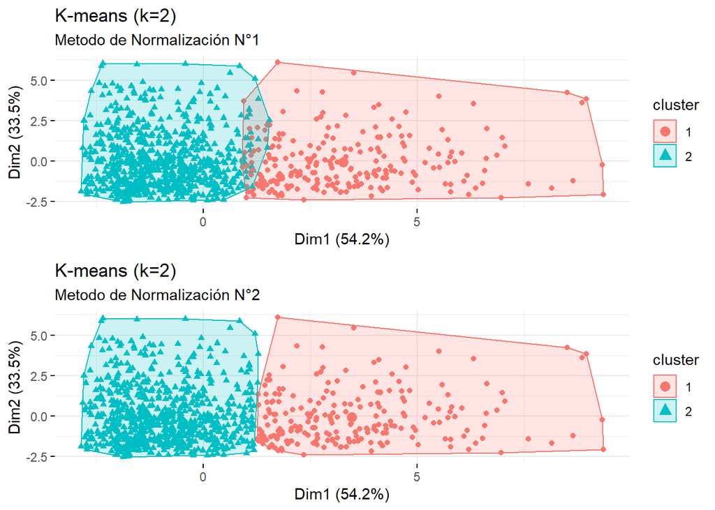

Claramente, el método 2 de normalización genera menor solapamiento entre los clusters.

## B. Coeficiente de Silhouette

1. Evaluamos la eficiencia de los clusters encontrados usando el coeficiente de silhouette:

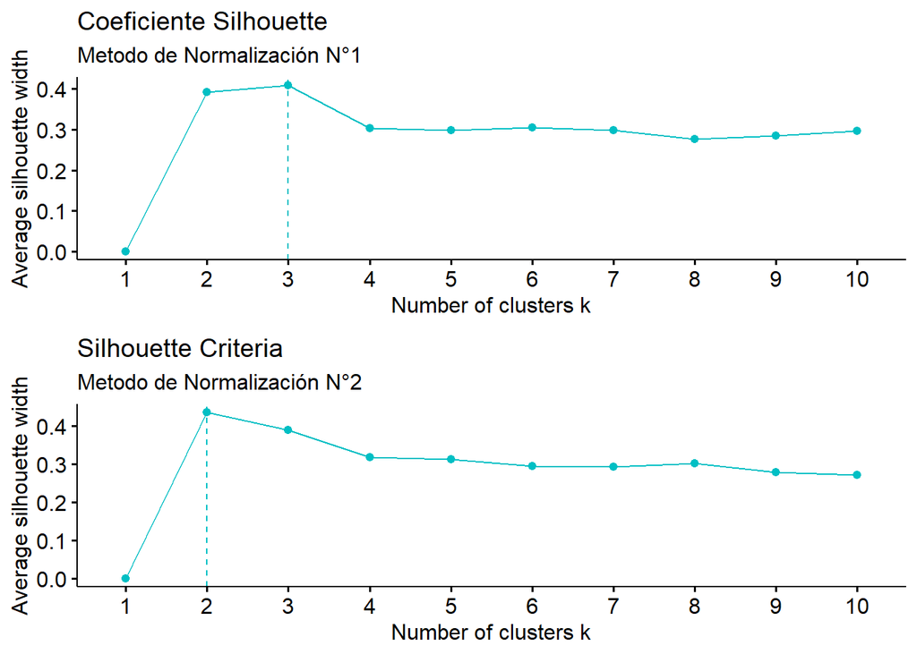

## C. Calinski-Harabaz Score

1. La eficiencia de los cluster podemos evaluarla también bajo el criterio Calinski-Harabaz:

| normalizacion | ch_score |
| --- | --- |
| método 1 | 474.6 |
| método 2 | 590.4 |

## D. Encontrando el cluster k óptimo

1. Estimaremos clusters hasta $k=7$ y evaluaremos cuál es el óptimo a partir de los distintos criterios (Silhouette o Calinski-Harabaz). Para cada método de normalización, visualizamos los respectivos clusters:

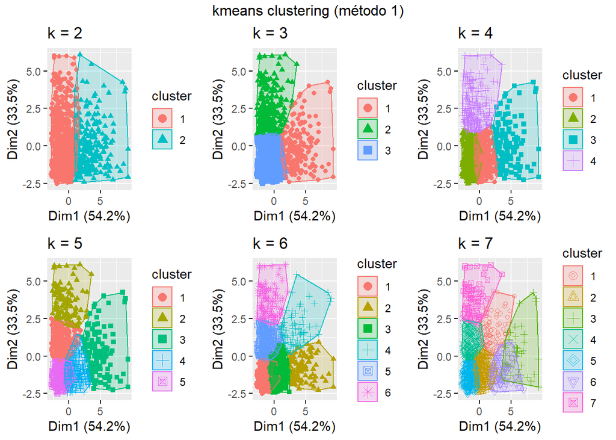

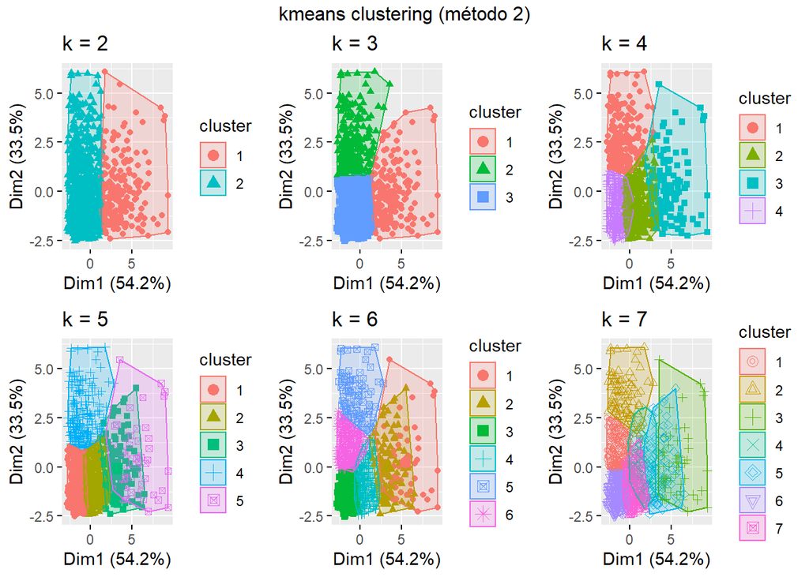

2. Graficamos los criterios Silhouette y Calinski-Harabaz conjuntamente para definir el número de $k$ clusters óptimo (según método de normalización):

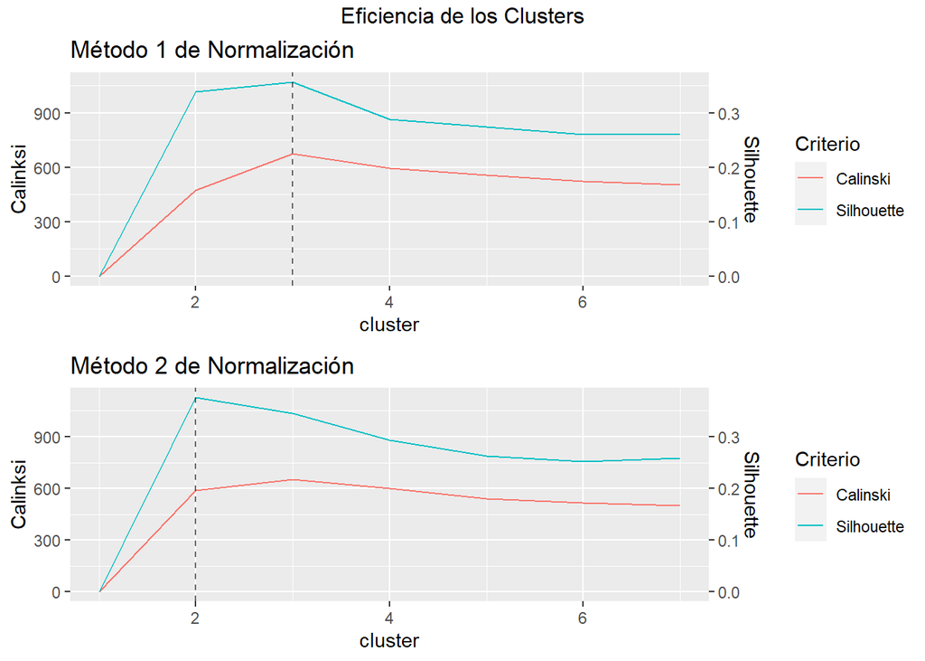